# lab4

Lucy Shao

February 24, 2017

### Q1

1a. The best offensive team at home (single variable and single grouping factor).Say we want to find the average points got for each team at home.

1. Use tapply() to find the average HomePoints by each HomeTeam. Display it.
2. Use aggregate() with the same arguments. Display it.

Which team has the highest average HomePoints? We note that both functions return the same values. tapply() returns a vector, but aggregate() returns a dataframe with two columns (the first column is HomeTeam and the second column is the average HomePoints).

```r
load("/Users/lucy/Desktop/NBA16BOX.Rdata")
tapply(nba16$HomePoints,nba16$HomeTeam, mean)
```

```
##          Atlanta Hawks         Boston Celtics          Brooklyn Nets
##              103.36957              105.79545               98.92683
##      Charlotte Hornets          Chicago Bulls    Cleveland Cavaliers
##              104.52273              101.82927              107.50980
##       Dallas Mavericks         Denver Nuggets        Detroit Pistons
##              104.34884              103.65854              104.55814
##  Golden State Warriors        Houston Rockets         Indiana Pacers
##              114.34545              105.76744              102.38636
##   Los Angeles Clippers     Los Angeles Lakers      Memphis Grizzlies
##              104.81818               96.80488              101.34884
##             Miami Heat        Milwaukee Bucks Minnesota Timberwolves
##              103.16667              100.85366              101.51220
##   New Orleans Pelicans        New York Knicks  Oklahoma City Thunder
##              105.92683               98.82927              109.46000
##          Orlando Magic     Philadelphia 76ers           Phoenix Suns
##              104.51220               98.07317              103.09756
## Portland Trail Blazers       Sacramento Kings      San Antonio Spurs
##              108.15217              107.56098              104.84783
##        Toronto Raptors              Utah Jazz     Washington Wizards
##              103.46154               98.56098              106.02439
```

```r
aggregate(nba16$HomePoints,list(as.factor(nba16$HomeTeam)), mean)
```

```
##                   Group.1         x
## 1           Atlanta Hawks 103.36957
## 2          Boston Celtics 105.79545
## 3           Brooklyn Nets  98.92683
## 4       Charlotte Hornets 104.52273
## 5           Chicago Bulls 101.82927
## 6     Cleveland Cavaliers 107.50980
## 7        Dallas Mavericks 104.34884
## 8          Denver Nuggets 103.65854
## 9         Detroit Pistons 104.55814
## 10  Golden State Warriors 114.34545
## 11        Houston Rockets 105.76744
## 12         Indiana Pacers 102.38636
## 13   Los Angeles Clippers 104.81818
## 14     Los Angeles Lakers  96.80488
```

[output cut: 16 more lines]

```r
which.max(tapply(nba16$HomePoints,nba16$HomeTeam, mean))
```

```
## Golden State Warriors
##                    10
```

```r
#Golden State Warriors has the highest average HomePoints
```

#### 1b. Numbers of home wins for each team in regular and post season (single variable and multiple grouping factors).

Say we want to find the number of wins for each team separated by regular season and playoffs. i. Create a new logical variable HomeWins by comparing HomePoints > VisitorPoints to the dataframe (TRUE: the home team won; FALSE: the home team lost). ii. Use tapply() to find the sum of HomeWins by each HomeTeam and Playoffs. Assign it to homewins_tapp. Display it. iii. Use aggregate() with the same arguments and assign it to homewins_agg. Display it. tapply() returns a 30 by 2 matrix, where rows represent teams and columns represent playoffs or regular season. Each cell shows the number of wins at home. On the other hand, aggregate() returns a dataframe where the first column shows the teams, the second column shows playoffs or regular season and the third column shows the number of wins at home. Note that, the missing value in tapply()’s output will not appear in aggregate()’s output.

```r
#i
HomeWins<-nba16$HomePoints>nba16$VisitorPoints
nba16<-cbind(nba16,HomeWins)
#ii
homewins_tapp<-tapply(nba16$HomeWins,list(nba16$HomeTeam,nba16$Playoffs), sum)
homewins_tapp
```

```
##                        Playoffs Regular Season
## Atlanta Hawks                 3             27
## Boston Celtics                2             28
## Brooklyn Nets                NA             14
## Charlotte Hornets             2             30
## Chicago Bulls                NA             26
## Cleveland Cavaliers           9             33
## Dallas Mavericks              0             23
## Denver Nuggets               NA             18
## Detroit Pistons               0             26
## Golden State Warriors        11             39
## Houston Rockets               1             23
## Indiana Pacers                2             26
## Los Angeles Clippers          2             29
## Los Angeles Lakers           NA             12
## Memphis Grizzlies             0             26
## Miami Heat                    5             28
## Milwaukee Bucks              NA             23
## Minnesota Timberwolves       NA             14
## New Orleans Pelicans         NA             21
## New York Knicks              NA             18
## Oklahoma City Thunder         6             32
## Orlando Magic                NA             23
## Philadelphia 76ers           NA              7
## Phoenix Suns                 NA             14
## Portland Trail Blazers        4             28
## Sacramento Kings             NA             18
## San Antonio Spurs             3             40
## Toronto Raptors               8             32
## Utah Jazz                    NA             24
## Washington Wizards           NA             22
```

```r
#iii
homewins_agg<-aggregate(nba16$HomeWins,list(nba16$HomeTeam,nba16$Playoffs), sum)
homewins_agg
```

```
##                   Group.1        Group.2  x
## 1           Atlanta Hawks       Playoffs  3
## 2          Boston Celtics       Playoffs  2
## 3       Charlotte Hornets       Playoffs  2
## 4     Cleveland Cavaliers       Playoffs  9
## 5        Dallas Mavericks       Playoffs  0
## 6         Detroit Pistons       Playoffs  0
## 7   Golden State Warriors       Playoffs 11
## 8         Houston Rockets       Playoffs  1
## 9          Indiana Pacers       Playoffs  2
## 10   Los Angeles Clippers       Playoffs  2
## 11      Memphis Grizzlies       Playoffs  0
## 12             Miami Heat       Playoffs  5
## 13  Oklahoma City Thunder       Playoffs  6
## 14 Portland Trail Blazers       Playoffs  4
```

[output cut: 32 more lines]

1c. Practice for converting output formats. Please convert the output from tapply() to aggregate()’s format. The dimension and the values should be identical.

```r
col1<-c(row.names(homewins_tapp[!is.na(homewins_tapp[ ,1]), ]),row.names(homewins_tapp))
col2<-c(rep("Playoffs",16),rep("Regular Season",30))
col3<-homewins_tapp[!is.na(homewins_tapp)]
m<-matrix(c(col1,col2,col3),nrow=46)
homewins_tapp<-as.data.frame(m)
colnames(homewins_tapp) <- c("Group.1","Group.2", "x")
homewins_tapp
```

```
##                   Group.1        Group.2  x
## 1           Atlanta Hawks       Playoffs  3
## 2          Boston Celtics       Playoffs  2
## 3       Charlotte Hornets       Playoffs  2
## 4     Cleveland Cavaliers       Playoffs  9
## 5        Dallas Mavericks       Playoffs  0
## 6         Detroit Pistons       Playoffs  0
## 7   Golden State Warriors       Playoffs 11
## 8         Houston Rockets       Playoffs  1
## 9          Indiana Pacers       Playoffs  2
## 10   Los Angeles Clippers       Playoffs  2
## 11      Memphis Grizzlies       Playoffs  0
## 12             Miami Heat       Playoffs  5
## 13  Oklahoma City Thunder       Playoffs  6
## 14 Portland Trail Blazers       Playoffs  4
```

[output cut: 32 more lines]

1d. The best defensive team at home in the regular season (multiple variables and multiple grouping factors). One huge advantage of aggregate() is that it takes multiple variables as input. Please use aggregate() to find the average HomePoints and VisitorPoints by each HomeTeam and Playoffs. It should return a dataframe where the first column shows the teams, the second column shows playoffs or regular season, and the third column shows the average HomePoints and the fourth shows the average VisitorPoints. Which team is the best defensive team at home in the regular season? [Hint: the lower the average VisitorPoints, the better the defense for the HoemTeam.]

```r
f<-aggregate(as.data.frame(cbind(nba16$HomePoints,nba16$VisitorPoints)),list(nba16$HomeTeam,nba16$Playoffs), mean)
f
```

```
##                   Group.1        Group.2        V1        V2
## 1           Atlanta Hawks       Playoffs 101.60000  95.40000
## 2          Boston Celtics       Playoffs 102.33333 100.66667
## 3       Charlotte Hornets       Playoffs  91.66667  87.33333
## 4     Cleveland Cavaliers       Playoffs 111.10000  93.20000
## 5        Dallas Mavericks       Playoffs 105.00000 125.00000
## 6         Detroit Pistons       Playoffs  94.50000 100.50000
## 7   Golden State Warriors       Playoffs 108.71429  97.14286
## 8         Houston Rockets       Playoffs  95.50000 108.50000
## 9          Indiana Pacers       Playoffs  95.33333  89.00000
## 10   Los Angeles Clippers       Playoffs 105.00000  94.66667
## 11      Memphis Grizzlies       Playoffs  91.00000 106.00000
## 12             Miami Heat       Playoffs 102.85714  90.00000
## 13  Oklahoma City Thunder       Playoffs 109.11111  95.77778
## 14 Portland Trail Blazers       Playoffs 109.00000 103.00000
```

[output cut: 32 more lines]

```r
min(f$V2[f$Group.2=="Regular Season"])
```

```
## [1] 91.17073
```

```r
###San Antonio Spurs is the best defensive team at home in the regular season
```

## 2. Generating Random Samples from a Normal Distribution (25 Points)

2a. Generate a random sample of length 100 from a normal distribution with mean = 2 and sd = 1. Follow the instruction below to sample from a normal distribution and reproduce the histogram: i. Set seed: set.seed(2017) ii. Use rnorm() to generate a random sample of length 100 from a normal distribution with mean = 2 andsd = 1andassignitasv. iii. Generate a histogram for v with freq = FALSE and breaks = 20. iv. Issue lines(density(v), col = ‘blue’) to add a density estimate for your random sample. v. Add a theoretical density curve to your histogram. vi. Add a legend.

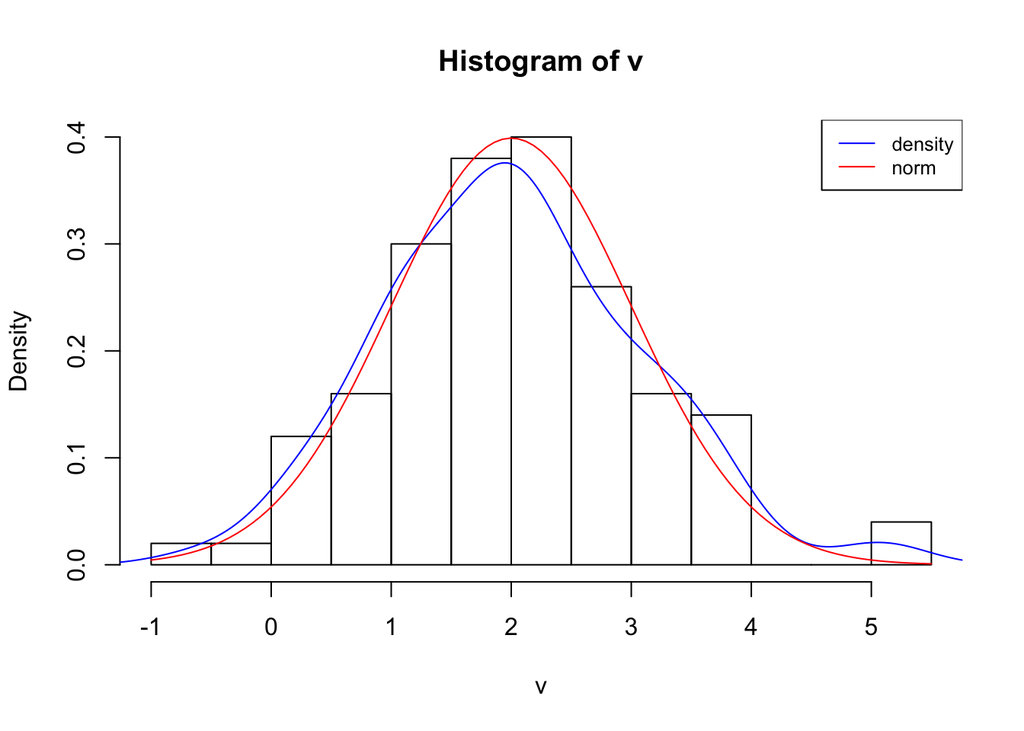

```r
set.seed(2017)
v <- rnorm(100, mean=2, sd=1)
hist(v,freq = FALSE, breaks = 20)
lines(density(v), col = 'blue')
curve(dnorm(x, mean=2, sd=1), add=TRUE,col='red')
legend("topright",legend=c("density", "norm"), col=c("blue","red"), lty=c(1,1), cex=0.8)
```

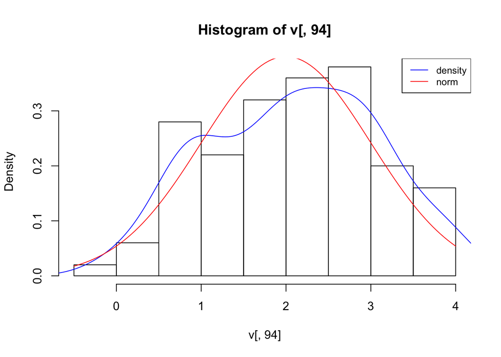

```r
set.seed(2017)
v <- rnorm(50000, mean=2, sd=1)
v<-matrix(v,nrow=100,ncol=500)
hist(v[,94],freq = FALSE, breaks = 10)
lines(density(v[,94]), col = 'blue')
curve(dnorm(x, mean=2, sd=1), add=TRUE,col='red')
legend("topright",legend=c("density", "norm"), col=c("blue","red"), lty=c(1,1), cex=0.8)
```

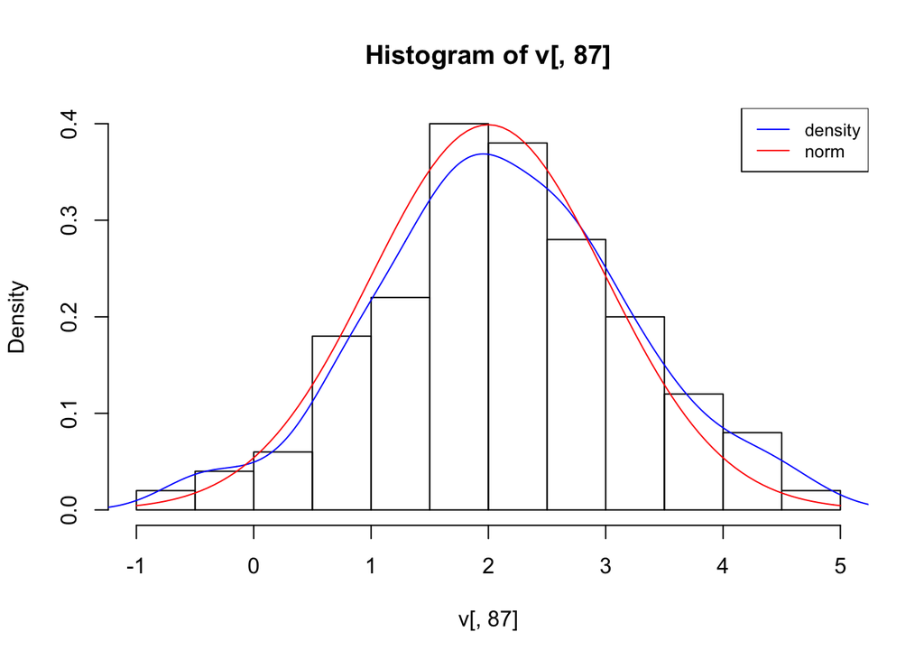

```r
hist(v[,87],freq = FALSE, breaks = 10)
lines(density(v[,87]), col = 'blue')
curve(dnorm(x, mean=2, sd=1), add=TRUE,col='red')
legend("topright",legend=c("density", "norm"), col=c("blue","red"), lty=c(1,1), cex=0.8)
```

2c. Sample means and sample standard deviations Please use apply() to calculate the sample means and the sample standard deviations for each sample. Generate histograms for the sample means and the sample standard deviations you found with freq = FALSE. Does it look like normally distributed? What is the average value for the sample means and sample standard deviations? What is the standard deviation of the sample means?

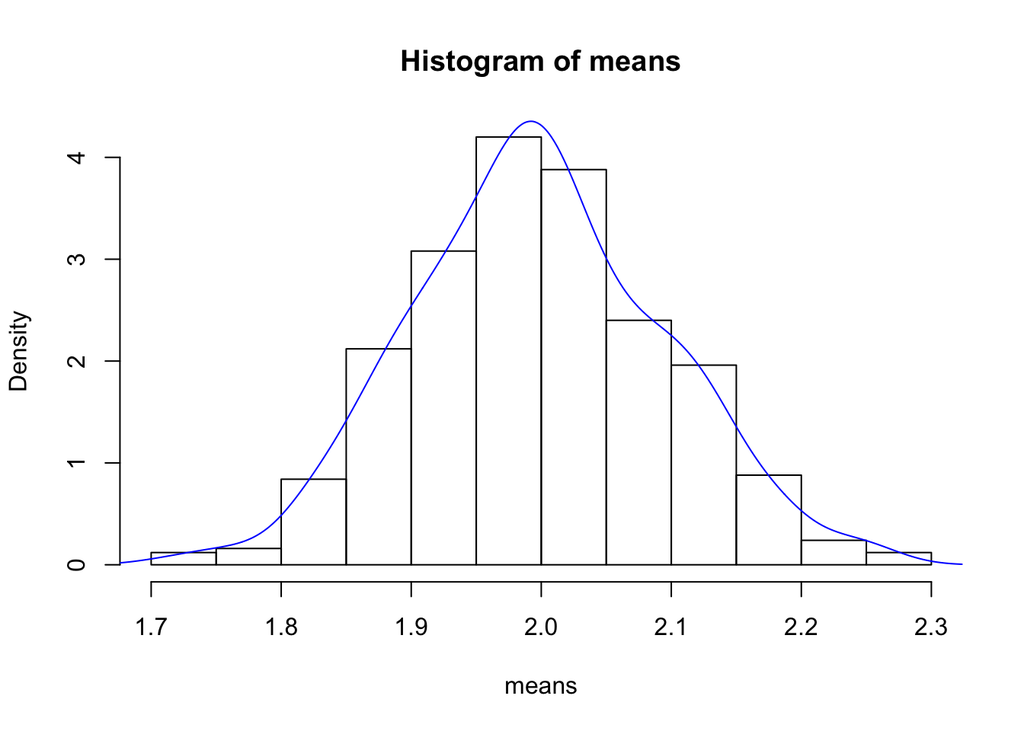

```r
means<-apply(v, 2, mean, na.rm = TRUE)
sds<-apply(v, 2, sd, na.rm = TRUE)
hist(means,freq = FALSE)
lines(density(means), col = 'blue')
```

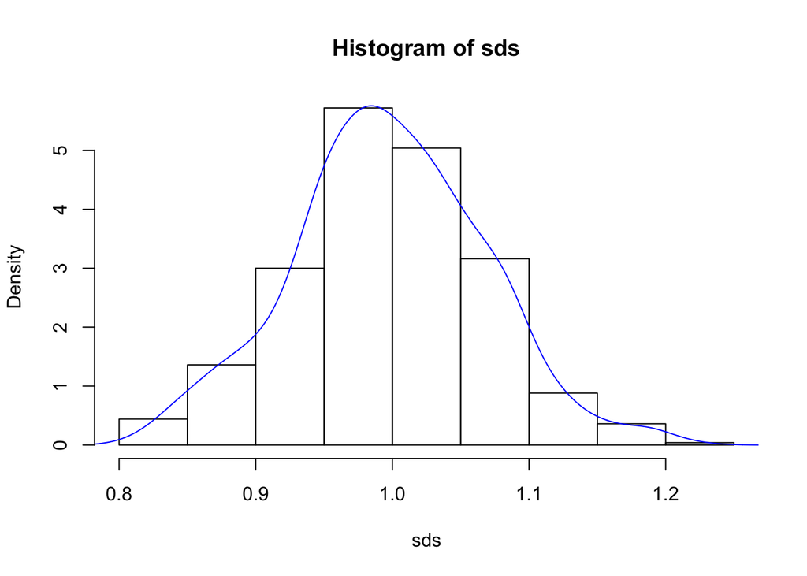

```r
hist(sds,freq = FALSE)
lines(density(sds), col = 'blue')
```

```r
#Does it look like normally distributed? Yes they do.
mean(means)
```

```
## [1] 1.997506
```

```r
mean(sds)
```

```
## [1] 0.997134
```

```r
#What is the average value for the sample means and sample standard deviations?1.997506 and 0.997134
sd(means)
```

```
## [1] 0.09716645
```

```r
#What is the standard deviation of the sample means? 0.09716645
```

## 3. rbinom(), runif() and sample() (25 points)

3a. Generate random numbers from a Bernoulli distribution using rbinom() The Bernoulli distribution is a special case of the binomial distribution with size = 1. Set the seed to be 2017. Use rbinom() to generate a random sample of length 1000 from Bernoulli distribution with success probability 0.4. Assign the random sample as a. Display a contingency table for a.

```r
set.seed(2017)
a<-rbinom(1000,1,0.4)
table(a)
```

```
## a
##   0   1
## 615 385
```

3b. Generate random numbers from a Bernoulli distribution using runif() Say we want to use runif() to generate a random sample of length 1000 from Bernoulli distribution with success probability p. Since runif() draws random values between 0 and 1 with equal chances, conceptually, if we split the interval [0, 1] into two intervals [0, 1 − p) and [1 − p, 1], the probability that the runif() returns in [0, 1 − p) is equal to 1 − p and the probability that the runif() returns in [1 − p, 1] is equal to 1 − (1 − p) = p. Thus, we can draw the Bernoulli sample from the following two steps: i. Use runif() to generate a random sample from uniform [0, 1] and assign it to u. ii. Use a comparison operator to return a logical vector indicating each element in u is greater than or equal to 1 − p or not. Convert it to a numeric vector and assign it as b.

```r
set.seed(2017)
u<-runif(1000,0,1)
b<-u>=0.6
table(b)
```

```
## b
## FALSE  TRUE
##   615   385
```

```r
#Is there any relationship between a and b. As the result shown the two methods results in same frequency that follows the bernoulli distribution.
```

3c. Sampling with replacement using runif() Draw a random sample of length 1000 from 1 to 10 with replacement using runif(). You can generate a random sample of length 1000 from a uniform distribution with minimum 0 and maximum 10 then use ceiling() to returns the smallest integers not less than each element.

```r
set.seed(2017)
un<-runif(1000,0,10)
c<-ceiling(un)
table(c)
```

```
## c
##   1   2   3   4   5   6   7   8   9  10
##  91 125  92 105  95 107 103  97  83 102
```